# Door-to-Door Waste Collection: a difference-in-difference analysis.

## Visualizze the data

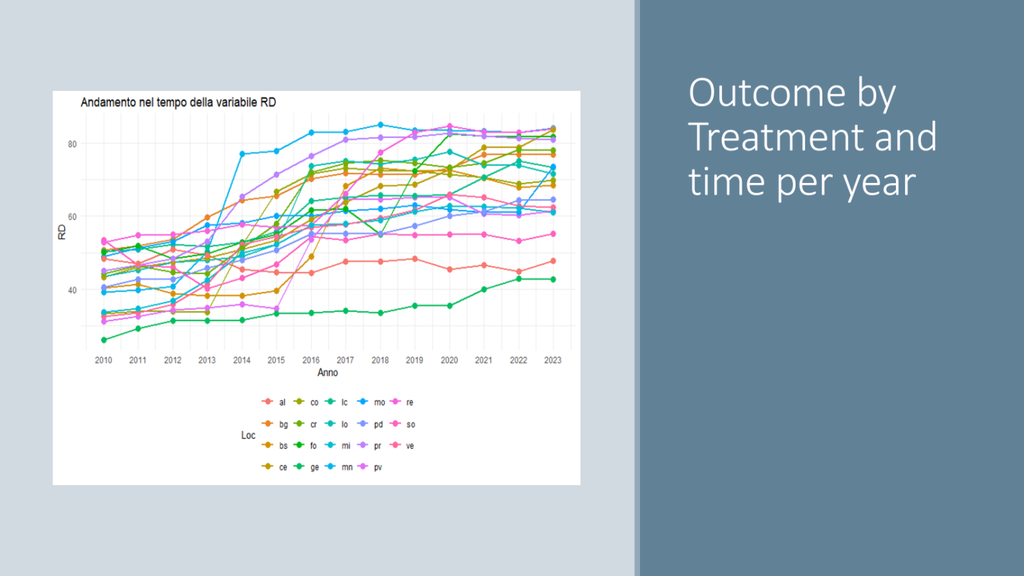

This is important to understand because in 2006 a legislative decree has been introduced to set a national objective of waste recycling for the year 2012: even if not all of the municipalities managed to achieve the objective proposed, financial found has been provided to the municipalities. Therefore:

- Reciclying in general may be higher after that law due to mandatory higher recycling responsability
- Effect of door-to-door policy before that year may be lower

## Treatment and Control Groups Over Time

Let’s visualize how our treatment and control groups change over time (base year = policy introduction).

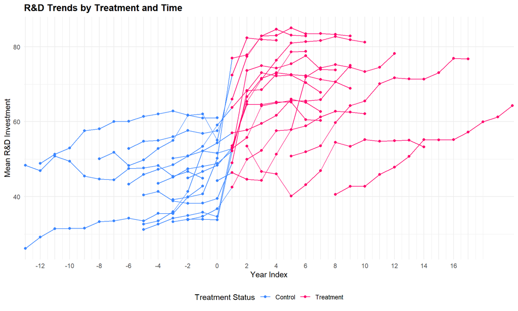

```r
# Summarize data by location, year, and treatment status
df_summary <- data %>%
  group_by(loc, year_ind, did) %>%
  summarise(mean_RD = mean(RD, na.rm = TRUE))

# Plot treatment and control over years
ggplot(df_summary, aes(x = year_ind, y = mean_RD, group = loc, color = factor(did))) +
  geom_line() +
  geom_point() +
  labs(
    title = "R&D Trends by Treatment and Time",
    x = "Year Index",
    y = "Mean R&D Investment",
    color = "Treatment Status"
  ) +
  theme_minimal() +
  theme(
    legend.position = "bottom",
    plot.title = element_text(face = "bold")
  ) +
  scale_x_continuous(
    breaks = seq(-13, 17, by = 1),
    labels = function(x) ifelse(x %% 2 == 0, x, ""),
    expand = c(0, 0.1)
  ) +
  scale_color_manual(
    values = c("0" = "#3A86FF", "1" = "#FF006E"),
    labels = c("0" = "Control", "1" = "Treatment")
  )
```

The graph shows how the introduction of the policy drastically improve the total waste sorting management. As said above some cities introduced their policy before 2010 and those are the one where the treatment point start after the year 0 on the X axis.

## Dynamic Treatment Effects

Let’s analyze the dynamic effects and the statistical significance of the treatment pre and post policy introduction

```r
# Fixed effects model with year indicators (base year = 0)
cali <- feols(RD ~ pop + Tot_RU + i(year_ind, , ref = 0),
              data = data)

# Display model results
etable(cali)
```

```
##                               cali
## Dependent Var.:                 RD
##
## Constant          49.79*** (3.007)
## pop             -2.81e-5 (2.14e-5)
## Tot_RU           3.44e-5 (4.31e-5)
## year_ind = -13     -12.20. (6.812)
## year_ind = -12      -8.287 (6.081)
## year_ind = -11      -5.252 (6.066)
## year_ind = -10      -4.741 (6.067)
## year_ind = -9       -4.733 (6.063)
## year_ind = -8       -3.118 (5.566)
## year_ind = -7       -2.183 (5.568)
## year_ind = -6       -1.741 (4.942)
## year_ind = -5       -4.968 (4.424)
## year_ind = -4       -3.844 (4.301)
## year_ind = -3       -4.328 (4.038)
## year_ind = -2       -2.410 (3.907)
## year_ind = -1       -1.067 (3.907)
## year_ind = 1        8.913* (4.126)
## year_ind = 2      16.79*** (4.057)
## year_ind = 3      19.13*** (4.056)
## year_ind = 4      20.98*** (4.054)
## year_ind = 5      20.13*** (4.066)
## year_ind = 6      21.01*** (4.064)
## year_ind = 7      19.31*** (4.241)
## year_ind = 8      20.16*** (4.518)
## year_ind = 9      20.17*** (4.626)
## year_ind = 10      17.10** (5.260)
## year_ind = 11       12.43* (6.073)
## year_ind = 12       14.34* (6.079)
## year_ind = 13        10.32 (6.811)
## year_ind = 14        11.18 (6.809)
## year_ind = 15       15.80. (8.078)
## year_ind = 16       17.65* (8.073)
## year_ind = 17       18.68* (8.076)
## year_ind = 18        11.98 (11.05)
## year_ind = 19        13.19 (11.05)
## year_ind = 20        16.03 (11.05)
## _______________ __________________
## S.E. type                      IID
## Observations                   260
## R2                         0.57288
## Adj. R2                    0.50614
## ---
## Signif. codes: 0 '***' 0.001 '**' 0.01 '*' 0.05 '.' 0.1 ' ' 1
```

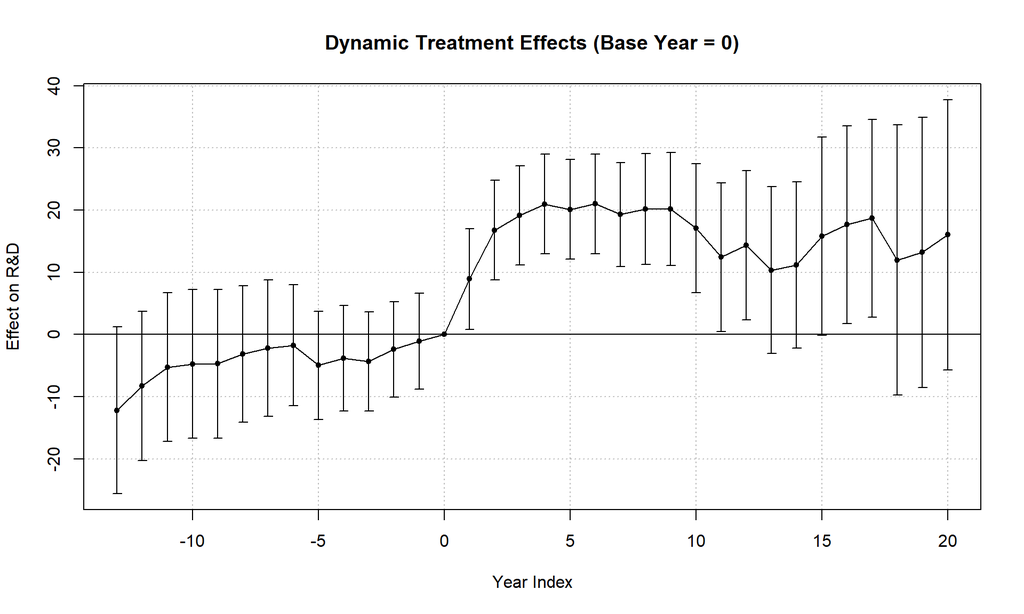

```r
# Plot dynamic effects
iplot(cali, pt.join = TRUE, main = "Dynamic Treatment Effects (Base Year = 0)",
      xlab = "Year Index", ylab = "Effect on R&D")
```

The following graph shows the effect of the policy introduction on significance levels, which is found in points where their respective bar stays above the base line.

Due to the different dates of the policy introduction, as higher as the number of years, the less is probbable that a municipality introudced the policy fot that long, hence less significancy.

## Empirical Results

Finally, let’s estimate the difference-in-differences model:

```r
# Simple DiD model
mod1 <- lm(RD ~ did, data = data)

# Calculate robust standard errors
mod1_ro_se <- sqrt(diag(vcovHC(mod1, type = "HC1")))

# Display results with robust standard errors
stargazer(mod1, type = "text", se = list(mod1_ro_se),
          digits = 6, header = FALSE,
          title = "Difference-in-Differences Estimation Results",
          notes = "Heteroskedasticity-robust standard errors in parentheses")
```

```
##
## Difference-in-Differences Estimation Results
## ============================================================================
##                                       Dependent variable:
##                     --------------------------------------------------------
##                                                RD
## ----------------------------------------------------------------------------
## did                                       21.068500***
##                                            (1.343372)
##
## Constant                                  44.392480***
##                                            (0.902506)
##
## ----------------------------------------------------------------------------
## Observations                                  260
## R2                                          0.478300
## Adjusted R2                                 0.476278
## Residual Std. Error                   10.989000 (df = 258)
## F Statistic                       236.537100*** (df = 1; 258)
## ============================================================================
## Note:                                            *p<0.1; **p<0.05; ***p<0.01
##                     Heteroskedasticity-robust standard errors in parentheses
```

Empirical results shows how significance is the introduction of our policy in terms of percentage on sorted waste.

As we can see an average effect of 21.07% is attributable to the policy introduction.

**Constant**: represents the avarage of RD for those cities where there is not door-to-door collection.

## Conclusion

The introduction of the door-to-door collection waste have a positive and significant impact on the treated group compared to the control group.

In particular the average effects of treated groups (who introduce door-to-door collection policy) show a medium increase of slightly more above 21% in recycling disposal percentage.

The population of each municipality and the overall production of waste do not affect the results.

## Possible weaknesses

We take into consideration just cities of the northern and center Italy, therefore it cannot be extended to all of the country as there are more differences not taken into account.

The percentage of waste collected depends also on factors that are difficult to measure and for this reason we did not include them, like for example the education and citizen awareness.